# SVM project

Luis Hernandez

10/11/2019

# 1 Introduction

This is an implementation of a support vector machine designed to identify short-term stock price changes, based on previous stock parameters: open, low, high, close, volume

## 1.1 Stock selected for this exercise:

I chose to use Starbucks stock becuase I have written a repot on this corporation in Managerial Economics. Please see the following graphs:

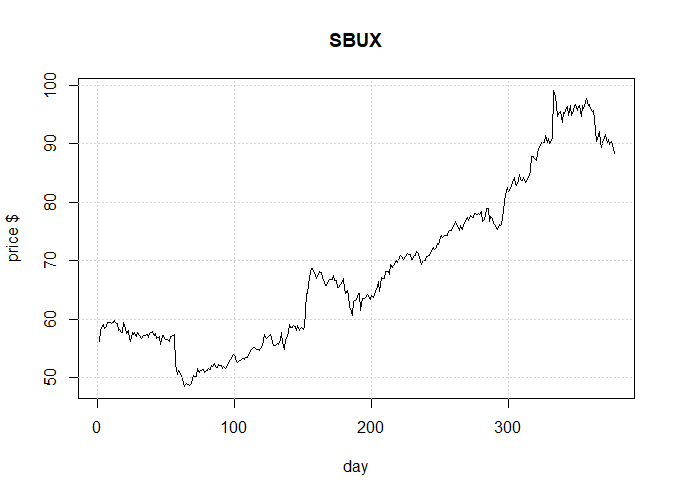

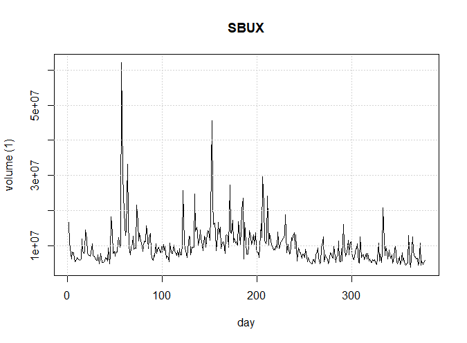

## 1.2 get data:

```r
SBUXData = read.csv('SBUX.csv')
View(SBUXData)
```

Names of the variables in the data set: price.open, price.high, price.low, price.close, volume, price.adjusted, ref.date’ ticker’ ret.adjusted.prices, ret.closing.prices’ pctChange. changeCategory

# 2 set up data frame

```r
    SBUXDataFrame = data.frame(open=SBUXData$price.open, high=SBUXData$price.high, low=SBUXData$price.low, close=SBUXData$price.close,volume= SBUXData$volume/10000,
      change = SBUXData$changeCategory )

# look at top and bottom..
head(SBUXDataFrame)
```

```
##    open  high   low close  volume change
## 1 56.55 58.05 56.45 58.00 1090.82   Even
## 2 57.25 58.97 57.21 58.83  789.31   Even
## 3 59.00 59.27 58.86 59.14  630.51   Even
## 4 58.78 59.14 58.09 58.34  826.45   Even
## 5 58.54 59.37 58.42 58.70  802.38   Even
## 6 59.11 59.49 58.87 59.41  654.50   Even
```

```r
tail(SBUXDataFrame)
```

```
##      open  high   low close  volume change
## 367 90.02 90.45 89.38 89.42  633.92   Even
## 368 89.67 91.46 89.65 90.75  649.32   Even
## 369 90.98 91.36 90.06 90.96  451.07   Even
## 370 90.99 92.10 90.30 91.56  484.36   Even
## 371 91.61 92.08 90.06 90.07 1091.38   Even
## 372 90.32 91.16 89.93 90.81  453.24   Less
```

```r
remove(SBUXData)
```

```r
levels(SBUXDataFrame$change)
```

```
## [1] "Even" "Less" "More"
```

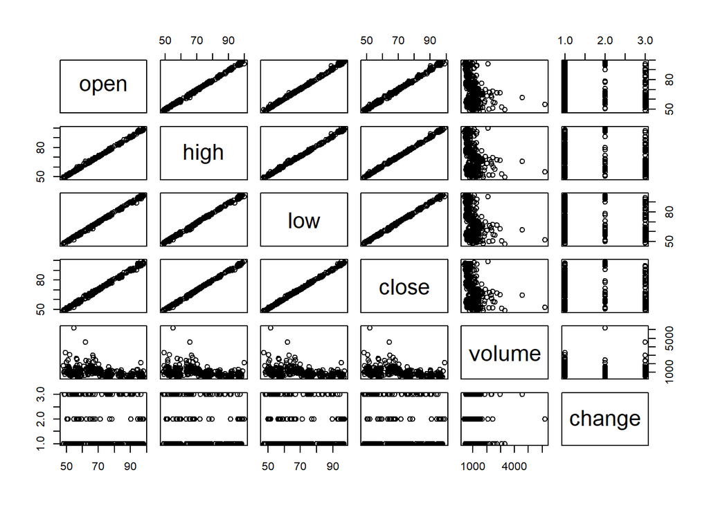

```r
plot(SBUXDataFrame)
```

## 2.1 classification model, categorical response

### 2.1.1 traditional interface:

```r
x <- subset(SBUXDataFrame[1:366,], select = -change)
y <- SBUXDataFrame[1:366,]$change
model1 <- svm(x, y)

#model1 is all the data
print(model1)
```

```
##
## Call:
## svm.default(x = x, y = y)
##
##
## Parameters:
##    SVM-Type:  C-classification
##  SVM-Kernel:  radial
##        cost:  1
##
## Number of Support Vectors:  212
```

```r
summary(model1)
```

```
##
## Call:
## svm.default(x = x, y = y)
##
##
## Parameters:
##    SVM-Type:  C-classification
##  SVM-Kernel:  radial
##        cost:  1
##
## Number of Support Vectors:  212
##
##  ( 122 35 55 )
##
##
## Number of Classes:  3
##
## Levels:
##  Even Less More
```

## 2.2 how well did the model fit?

```r
pred <- predict(model1, x)

# Check accuracy:
table(pred, y)
```

```
##       y
## pred   Even Less More
##   Even  276   33   54
##   Less    0    2    0
##   More    0    0    1
```

## 2.3 decision values

```r
# compute decision values and probabilities:
pred <- predict(model1, x, decision.values = TRUE)
attr(pred, "decision.values")[1:6,]
```

```
##   Even/Less Even/More   Less/More
## 1 0.9995256 1.0006786 -0.55414852
## 2 0.9998209 0.9999549 -0.20364355
## 3 1.0000268 0.9998789  0.01858152
## 4 1.0001647 1.0000717 -0.17854788
## 5 1.0002414 1.0000711 -0.13314372
## 6 1.0000308 0.9998952  0.02451163
```

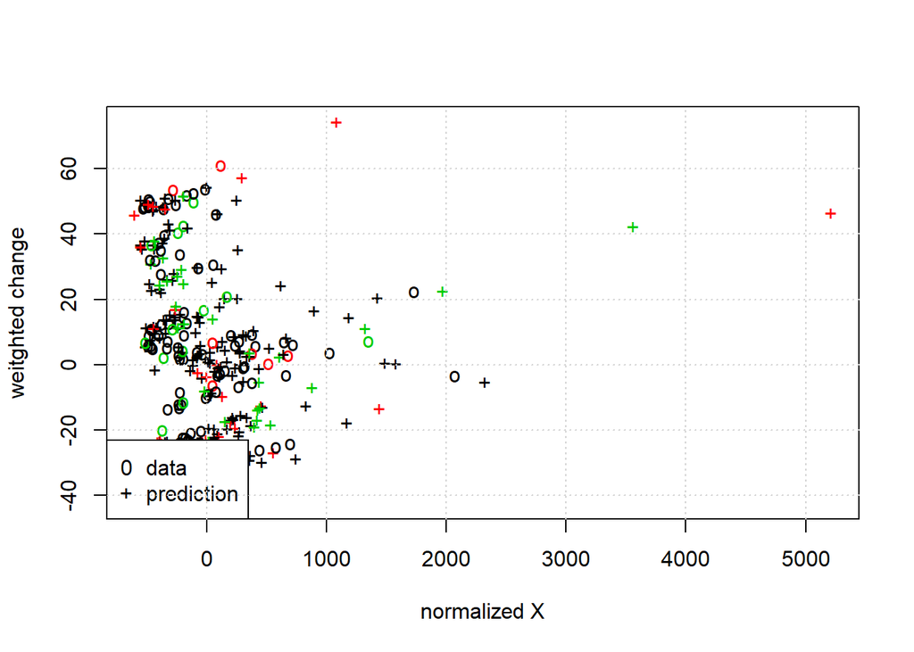

```r
# visualize (classes by color, SV by crosses):
plot(cmdscale(dist(SBUXDataFrame[,-6])),
     col = as.integer(SBUXDataFrame[,6]),xlab="normalized X", ylab = "weitghted change",
     pch = c("o","+")[1:150 %in% model1$index + 1])
legend('bottomleft',c('data','prediction'),pch=c('0','+'))
grid()
```

# 3 train and test set:

```r
pctTrain=0.70 # use 70% of the data
#nObs = length(x[,1])
nObs = 366
nTrain = round(pctTrain*nObs,0)

# next line take data in order
#TrainSetIndex = 1:nTrain

#These lineas are a random sample
scramble = sample (1:nObs)
TrainSetIndex = scramble[1:nTrain]
TestSetIndex = scramble[(nTrain+1):nObs]
```

## 3.1 set up training set, test set

```r
# first the training set

SBUXDataFrame1 = SBUXDataFrame[1:366,]

XtrainSet = SBUXDataFrame1[TrainSetIndex,-6]
YtrainSet = SBUXDataFrame1$change[TrainSetIndex]
```

## 3.2 get the model from training set..

This is model2

```r
model2 <- svm(XtrainSet, YtrainSet)

print(model2)
```

```
##
## Call:
## svm.default(x = XtrainSet, y = YtrainSet)
##
##
## Parameters:
##    SVM-Type:  C-classification
##  SVM-Kernel:  radial
##        cost:  1
##
## Number of Support Vectors:  152
```

```r
summary(model2)
```

```
##
## Call:
## svm.default(x = XtrainSet, y = YtrainSet)
##
##
## Parameters:
##    SVM-Type:  C-classification
##  SVM-Kernel:  radial
##        cost:  1
##
## Number of Support Vectors:  152
##
##  ( 91 36 25 )
##
##
## Number of Classes:  3
##
## Levels:
##  Even Less More
```

## 3.3 now the test set..

```r
XtestSet = SBUXDataFrame[(nTrain:nObs),-6]
YtestSet = SBUXDataFrame1$change[nTrain:nObs]
```

## 3.4 and evaluate with the test data

```r
pred2 <- predict(model2, XtestSet)
# And the accuracy..

table(pred2, YtestSet)
```

```
##       YtestSet
## pred2  Even Less More
##   Even   80    9   21
##   Less    0    1    0
##   More    0    0    0
```

## 3.5 tune

```r
stockTuned <- tune.svm(XtrainSet, YtrainSet, gamma = 2^(-2:1), cost = 2^(1:4))

summary(stockTuned)
```

```
##
## Parameter tuning of 'svm':
##
## - sampling method: 10-fold cross validation
##
## - best parameters:
##  gamma cost
##      1   16
##
## - best performance: 0.2343077
##
## - Detailed performance results:
##    gamma cost     error dispersion
## 1   0.25    2 0.2420000 0.05630316
## 2   0.50    2 0.2418462 0.06396416
## 3   1.00    2 0.2498462 0.05723959
## 4   2.00    2 0.2460000 0.05755231
## 5   0.25    4 0.2458462 0.06228521
## 6   0.50    4 0.2458462 0.05936238
## 7   1.00    4 0.2578462 0.06116640
## 8   2.00    4 0.2461538 0.04888231
## 9   0.25    8 0.2458462 0.05936238
## 10  0.50    8 0.2458462 0.05936238
## 11  1.00    8 0.2461538 0.06086382
## 12  2.00    8 0.2535385 0.06254224
## 13  0.25   16 0.2498462 0.05723959
## 14  0.50   16 0.2460000 0.06802347
## 15  1.00   16 0.2343077 0.06065195
## 16  2.00   16 0.2730769 0.06415075
```

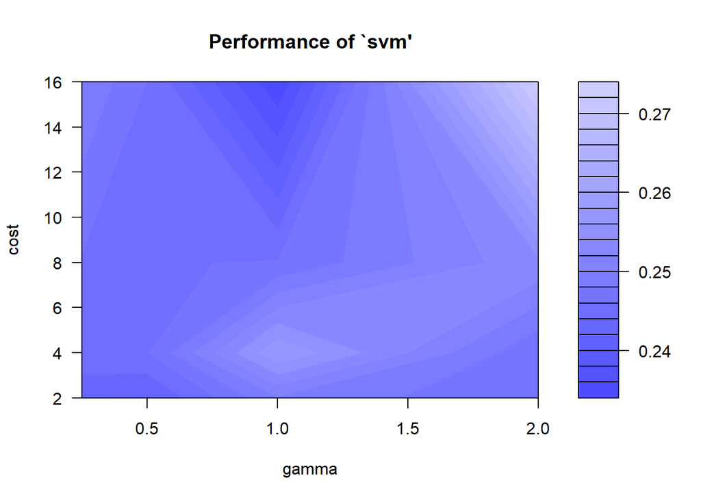

```r
plot(stockTuned)
```

```r
print(paste('best parameters: gamma=',stockTuned$best.parameters[1], ', cost=', stockTuned$best.parameters[2]))
```

```
## [1] "best parameters: gamma= 1 , cost= 16"
```

```r
#use optimized parameters...
model3 <- svm(XtrainSet, YtrainSet, gamma=as.numeric(stockTuned$best.parameters[1]), cost=as.numeric(stockTuned$best.parameters[2] ))

print(model3)
```

```
##
## Call:
## svm.default(x = XtrainSet, y = YtrainSet, gamma = as.numeric(stockTuned$best.parameters[1]),
##     cost = as.numeric(stockTuned$best.parameters[2]))
##
##
## Parameters:
##    SVM-Type:  C-classification
##  SVM-Kernel:  radial
##        cost:  16
##
## Number of Support Vectors:  151
```

```r
summary(model3)
```

```
##
## Call:
## svm.default(x = XtrainSet, y = YtrainSet, gamma = as.numeric(stockTuned$best.parameters[1]),
##     cost = as.numeric(stockTuned$best.parameters[2]))
##
##
## Parameters:
##    SVM-Type:  C-classification
##  SVM-Kernel:  radial
##        cost:  16
##
## Number of Support Vectors:  151
##
##  ( 90 36 25 )
##
##
## Number of Classes:  3
##
## Levels:
##  Even Less More
```

```r
pred3 <- predict(model3, XtestSet)
# And the accuracy..

table(pred3, YtestSet)
```

```
##       YtestSet
## pred3  Even Less More
##   Even   80    7   21
##   Less    0    3    0
##   More    0    0    0
```

Use the last 5 values to see how we do

```r
XtestSetFortheMoney = SBUXDataFrame[367:371,-6]
YtestSetFortheMoney  = SBUXDataFrame[367:371,6]

pred4 <- predict(model3, XtestSetFortheMoney)
# And the accuracy..
print(pred4)
```

```
##  367  368  369  370  371
## Even Even Even Even Even
## Levels: Even Less More
```

```r
#table(pred4, YtestSetFortheMoney)
```

```r
# compute decision values and probabilities:
pred <- predict(model3, XtestSet, decision.values = TRUE)
attr(pred, "decision.values")[1:6,]
```

```
##     Even/More Even/Less   More/Less
## 256 1.3208617 1.0368649 -0.34464138
## 257 1.4152667 1.0077090 -0.60535459
## 258 1.2267841 1.0411127  0.13446986
## 259 1.2695011 1.0191191 -0.04031889
## 260 1.5687293 0.9825491 -1.10395907
## 261 0.9999388 1.0566249  1.32367480
```

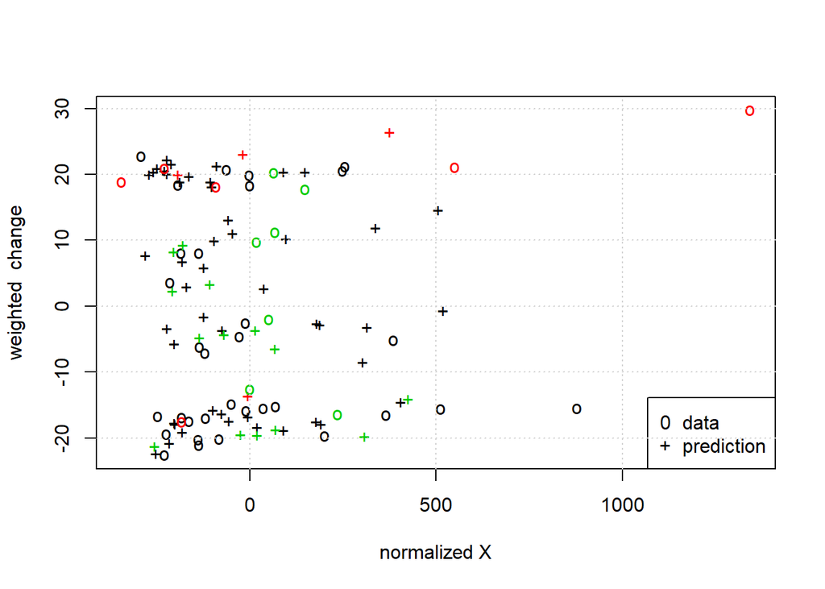

```r
# visualize (classes by color, SV by crosses):
plot(cmdscale(dist(XtestSet)),
     col = as.integer(YtestSet),xlab="normalized X", ylab = "weighted  change",
     pch = c("o","+")[1:150 %in% model3$index + 1])
legend('bottomright',c('data','prediction'),pch=c('0','+'))
grid()
```

# 4 SVM assignment

## 4.1 complete an rmarkdown file on the stock you selected.

You will turn in the URL for your github accout that has the repo for this assignment.

### 4.1.1 Identify the stock you use for this assignment.

Why did you choose this particular stock? I thought it had variability.

### 4.1.2 Use this template to get the SVM:

1. Training and Test sets:

```
I used 70% of the data for the training set.
I selescted the training set using a random sample.
```

3. Tune the algorithm- i.e. find optimal gamma and cost values.

### 4.1.3 Evaluate SVM performance

1. Did you exmine using other than the ‘open’, ‘low’, ‘high’, ‘close’ prices and volume as predictors?

I did not

3. Would you put your own $$ in this SVM?

No I would not.